# Calculating home-range overlaps with `amt`

Johannes Signer and John Fieberg

2022-02-22

## Background

Several different indices have been proposed for measuring home-range overlap. These are reviewed by Fieberg & Kochany (2005)[^1]. There are two general approaches used to calculate home-range overlap: 1) calculate the percentage overlap at a given isopleth level (this works for geometric and probabilistic home ranges) or 2) calculate an index of similarity between the two utilization distributions (UD; this only works for probabilistic estimators)[^2].

## Implementation in `amt`

`amt` currently implements all methods to calculate overlaps that were reviewed by Fieberg and Kochany (2005). These are:

- `hr`: That is the proportion of the home range of instance $i$ that overlaps with the home range of instance $j$. This measure does not rely on a UD and is directional (i.e., $HR_{i,j} \ne HR_{j,i}$) and bound between 0 (no overlap) and 1 (complete overlap)
- `phr`: Is the probability of instance $j$ being located in the home range of instance $i$. `phr` is also directional and bounded between 0 (no overlap) and 1 (complete overlap)
- `vi`: The volumetric intersection between two UDs.
- `ba`: The Bhattacharyya’s affinity between two UDs.
- `udoi`: A UD overlap index.
- `hd`: Hellinger’s distance between two UDs.

These overlap indices can be calculated with the function `hr_overlap`. The type of overlap measure an be controlled with the argument `type`.

All of these estimators can be calculated for a given home-range level (i.e., using conditional UDs). Whether or not a conditional overlap is desired or not, can be controlled with the argument `conditional`. For `hr`, the argument `conditional` has no effect and the isopleths used for home-range estimation will always be used for the overlap calculation.

The function `hr_overlap()` can also be provided with a list of home-range estimates in situations when overlap between many different instances are required. Currently, there are three options for calculating overlap among multiple instances: `which = "all"` calculates overlap for each pair of home ranges, `which = "one_to_all"` calculates overlap between the first element in the list and all others, and `which = "consecutive"` will calculate overlap between consecutive elements in the list.

## Examples

First we need to load the required packages:

```r
library(amt)
library(ggplot2)
library(tidygraph)
library(ggraph)
```

### Two instances

We will use tracking data from Fishers from New York State, USA.

```r
leroy <- amt_fisher %>% filter(name == "Leroy")
lupe <- amt_fisher %>% filter(name == "Lupe")
```

Create a template raster for the KDE

```r
trast <- make_trast(amt_fisher %>% filter(name %in% c("Leroy", "Lupe")), res = 50)
```

And estimate home-ranges for both fishers

```r
hr_leroy <- hr_kde(leroy, trast = trast, levels = c(0.5, 0.9))
hr_lupe <- hr_kde(lupe, trast = trast, levels = c(0.5, 0.9))
```

`hr` and `phr` are directional, this means the order matters. For all other overlap measures the order does not matter.

```r
hr_overlap(hr_leroy, hr_lupe, type = "hr")
```

```
## # A tibble: 2 × 2
##   levels overlap
##    <dbl>   <dbl>
## 1    0.9   0.309
## 2    0.5   0.191
```

```r
hr_overlap(hr_lupe, hr_leroy, type = "hr")
```

```
## # A tibble: 2 × 2
##   levels overlap
##    <dbl>   <dbl>
## 1    0.9   0.986
## 2    0.5   0.574
```

By default `conditional = FALSE` and the full UD is used.

```r
hr_overlap(hr_leroy, hr_lupe, type = "phr", conditional = FALSE)
```

```
## # A tibble: 1 × 2
##   levels overlap
##    <dbl>   <dbl>
## 1      1       1
```

```r
hr_overlap(hr_lupe, hr_leroy, type = "phr", conditional = FALSE)
```

```
## # A tibble: 1 × 2
##   levels overlap
##    <dbl>   <dbl>
## 1      1   0.723
```

If we set `conditional = TRUE`, the overlap is measured at home-range levels that were specified during estimation.

```r
hr_overlap(hr_leroy, hr_lupe, type = "phr", conditional = TRUE)
```

```
## # A tibble: 2 × 2
##   levels overlap
##    <dbl>   <dbl>
## 1    0.5   0.582
## 2    0.9   0.992
```

```r
hr_overlap(hr_lupe, hr_leroy, type = "phr", conditional = TRUE)
```

```
## # A tibble: 2 × 2
##   levels overlap
##    <dbl>   <dbl>
## 1    0.5   0.221
## 2    0.9   0.401
```

Note, for the remaining overlap measures the order does not matter. Below we show this for the volumnic intersection (`type = "vi"`) as an example.

```r
hr_overlap(hr_lupe, hr_leroy, type = "vi", conditional = FALSE)
```

```
## # A tibble: 1 × 2
##   levels overlap
##    <dbl>   <dbl>
## 1      1   0.439
```

```r
hr_overlap(hr_leroy, hr_lupe, type = "vi", conditional = FALSE)
```

```
## # A tibble: 1 × 2
##   levels overlap
##    <dbl>   <dbl>
## 1      1   0.439
```

### $> 2$ instances

We have to use the same template raster in order to make ranges comparable.

```r
trast <- make_trast(lupe, res = 50)
```

```r
dat <- lupe %>%
  mutate(week = lubridate::floor_date(t_, "week")) %>%
  nest(data = -week) %>%
  mutate(kde = map(data, hr_kde, trast = trast, levels = c(0.5, 0.95, 0.99)))
```

Now we can use the list column with the home-range estimates to calculate overlap between the different home-ranges. By default `which = "consecutive"`, this means for each list entry (= home-range estimate) the overlap to the next entry will be calculated.

```r
hr_overlap(dat$kde, type = "vi")
```

```
## # A tibble: 3 × 4
##    from    to levels overlap
##   <int> <int>  <dbl>   <dbl>
## 1     1     2      1  0.0432
## 2     2     3      1  0.551
## 3     3     4      1  0.612
```

This works as well, if we set `conditional = TRUE`:

```r
hr_overlap(dat$kde, type = "vi", conditional = TRUE)
```

```
## # A tibble: 9 × 4
##    from    to levels overlap
##   <int> <int>  <dbl>   <dbl>
## 1     1     2   0.5   0
## 2     1     2   0.95  0.0264
## 3     1     2   0.99  0.0354
## 4     2     3   0.5   0.259
## 5     2     3   0.95  0.528
## 6     2     3   0.99  0.547
## 7     3     4   0.5   0.317
## 8     3     4   0.95  0.592
## 9     3     4   0.99  0.608
```

Sometimes it can be useful to provide meaningful labels. We can do this with the `labels` argument.

```r
hr_overlap(dat$kde, type = "vi", labels = dat$week)
```

```
## # A tibble: 3 × 4
##   from       to         levels overlap
##   <chr>      <chr>       <dbl>   <dbl>
## 1 2010-12-12 2010-12-19      1  0.0432
## 2 2010-12-19 2010-12-26      1  0.551
## 3 2010-12-26 2011-01-02      1  0.612
```

Different options exist for the argument `which`. For example, `which = "one_to_all"` calculates the overlap between the first and all other home ranges.

```r
data("puechabonsp", package = "adehabitatMA")
dat <- puechabonsp$relocs %>% as.data.frame() %>%
  make_track(X, Y, id = Name)
trast <- make_trast(dat, res = 50)
dat1 <- dat %>% nest(data = -id) %>%
  mutate(kde = map(data, ~ hr_kde(., trast = trast, level = c(0.5, 0.9, 0.99))))
```

Now we can calculate the overlaps between animals:

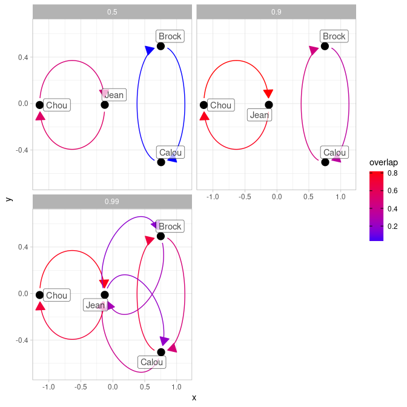

```r
ov2 <- hr_overlap(dat1$kde, type = "hr", labels = dat1$id, which = "all",
                  conditional = TRUE) %>%
  filter(overlap > 0)
graph <- as_tbl_graph(ov2) %>%
  mutate(Popularity = centrality_degree(mode = 'in'))

ggraph(graph, layout = 'stress') +
  #geom_edge_fan(aes(col = overlap), show.legend = TRUE, arrow = arrow()) +
  geom_edge_arc(aes(col = overlap), arrow = arrow(length = unit(4, 'mm'), type = "closed"),
                start_cap = circle(3, 'mm'),
                end_cap = circle(3, 'mm')) +
  geom_node_point(size = 4) +
  geom_node_label(aes(label = name), repel = TRUE, alpha = 0.7) +
  facet_edges(~ levels, ncol = 2) +
  theme_light() +
  scale_edge_color_gradient(low = "blue", high = "red")
```

## Overlap between a home range and a simple feature

The function `hr_overlap_feature` allows to calculate percentage overlap ($HR$ index) between a home. To illustrate this feature, we will use again the data from `lupe` and calculate the intersection with an arbitrary polygon.

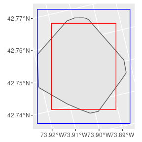

```r
poly <- bbox(lupe, buffer = -500, sf = TRUE)
poly1 <- bbox(lupe, sf = TRUE)
hr <- hr_mcp(lupe)
ggplot() + geom_sf(data = hr_isopleths(hr)) +
  geom_sf(data = poly, fill = NA, col = "red") +
  geom_sf(data = poly1, fill = NA, col = "blue")
```

```r
hr_overlap_feature(hr, poly, direction = "hr_with_feature")
```

```
## # A tibble: 1 × 3
##    from    to overlap
##   <dbl> <int>   <dbl>
## 1  0.95     1   0.828
```

```r
hr_overlap_feature(hr, poly1, direction = "hr_with_feature")
```

```
## # A tibble: 1 × 3
##    from    to overlap
##   <dbl> <int>   <dbl>
## 1  0.95     1    1.00
```

```r
hr_overlap_feature(hr, poly, direction = "feature_with_hr")
```

```
## # A tibble: 1 × 3
##    from    to overlap
##   <int> <dbl>   <dbl>
## 1     1  0.95   0.854
```

```r
hr_overlap_feature(hr, poly1, direction = "feature_with_hr")
```

```
## # A tibble: 1 × 3
##    from    to overlap
##   <int> <dbl>   <dbl>
## 1     1  0.95   0.542
```

The same work with several home-range levels:

```r
hr <- hr_mcp(lupe, levels = c(0.5, 0.9, 0.95))
hr_overlap_feature(hr, poly, direction = "hr_with_feature")
```

[output not shown]

## Todo

ctmm implements overlap for stationary dist with ci: https://besjournals.onlinelibrary.wiley.com/doi/10.1111/2041-210X.13027

[^1]: https://wildlife.onlinelibrary.wiley.com/doi/abs/10.2193/0022-541X%282005%2969%5B1346%3AQHOTIO%5D2.0.CO%3B2
[^2]: For a discussion of geometric vs. probabilistic estimators see here: https://www.biorxiv.org/content/10.1101/2020.08.19.256859v2